# Statistical Performance Index - Availability of Key Indicators

# Overview

DECIS has been tasked with coming up with a set of roughly 12 indicators for the Availability of Key Indicators (AKI) dimension of the Statistical Performance Index (SPI). Based on feedback from the concept note of the SPI, the SPI team has requested the indicators for the AKI:

1. Cover topic areas (i.e. the SDGs) as well as possible (for instance, in the current set of indicators below there is no coverage of environmental SDGs). Tier 1 SDG indicators are preferred
2. The indicators must be (as much as possible) produced by the country statistical systems, so as to measure statistical capacity. Not modelled estimates.
3. Included in the WDI.

I am continually updating a dashboard to help us with the indicator selection here: https://datanalytics.worldbank.org/content/435

## Statistical Performance Index Overview

The SPI framework is designed to capture different aspects of national statistical capacity by employing most relevant and representative variables that are publicly available. The SPI can be used to gauge statistical performance of individual countries over time or cross-country comparisons of performance at a point in time.

The SPI aims to provide an objective, justifiable/verifiable assessment of the statistical performance of countries over time by using publicly available information from international agencies and country websites that were produced by national statistical systems. The SPI framework helps countries and development partners identify the strengths and weaknesses of national statistical systems and areas of potential improvements. It could also provide actionable guidance for national statistical systems in areas that may require further and deeper assessment. Key characteristics of the SPI are:

- Uses only publicly accessible data
- Transparent methodology
- Easily replicable
- Provides a long-time series to track progress in performance
- Captures outcomes and supporting elements
- Reflects the SDGs.
- Facilitates at-a-glance comparisons on a global scale

A recent paper by Cameron et al. (2019) provides the conceptual foundation for SPI in measuring the ability of NSS to produce high quality data to inform national and international policy decisions

### General Notes

We could consider adding a metric on whether administrative data or private sector data is utilized by the statistical system. This is what a modern statistical system should be able to do.

## Availability of Key Indicators (AKI) Overview

Transforming source data into statistical outputs (indicators) and releasing them on a timely basis shows that the statistical systems are utilizing their capacity in data production. Reporting relevant data to specialized international agencies on time and getting them published in their respective databases demonstrates that statistical systems meet required quality standards and timeliness. Therefore, this dimension evaluates national statistical systems by reviewing the availability of country data for the most recent year in international databases. By looking at the data availability in international databases, it also makes the assessment cost-effective.

The selection of the indicators under the AKI dimension is based on the following principles:

- It should provide some assessment of national statistical performance, i.e. the indicators should be produced by countries;
- The availability of indicators should be verifiable, with established standards and methodologies in producing the statistics.
- It should help address the development concerns of countries, especially with SDGs. Nine indicators included in this category overlap to large extent with the Tier 1 SDG list that are conceptually clear, established methodology and standards are available and data regularly produced by countries;

These selected indicators cover key socio-economic and SDG indicators that have well established standards and methodology in the area of poverty, health, education, and economic development. It is assumed that if national statistical systems have capacity in the first two dimensions they should be able to produce these selected indicators.

# Initial Set of Indicators

| Indicator | Score 1 - Data is available once in three years, prior to reference year | Score 0 |
| --- | --- | --- |
| Poverty headcount ratio at national poverty lines/ availability of similar key indicators | Yes | No |
| Mortality rate, under-5 (per 1,000 live births) | Yes | No |
| Child immunization (proportion of one-year-old children immunized against measles) | Yes | No |
| Primary completion rate, both sexes (%) | Yes | No |
| Adult literacy rate, population 15+ years, both sexes (%) | Yes | No |
| Proportion of population using at least basic drinking water services (%) | Yes | No |
| Unemployment, total (% of total labor force) | Yes | No |
| Manufacturing value added as a proportion of GDP | Yes | No |
| Gross capital formation (% of GDP) | Yes | No |
| GDP implicit price deflator (annual % growth) | Yes | No |
| Net trade in goods and services (BoP, current US$) | Yes | No |
| Prevalence of undernourishment (% of population) | Yes | No |

# Final Set of Indicators After Analysis

After consultation with WDI team, we decided to compose the AKI from 15 indicators chosen from the first 10 SDGs, 2 from environmental indicators, and 3 from national accounts.

## New AKI Indicator Set

Choosing among the indicators we received from WDI experts on important indicators, below is the chosen list:

## Notes

### Poverty

Poverty headcount data includes some footnotes on Estimated from unit-record consumption data.

### Hunger

Undernourishment data contains no footnote data for observations

### Good Health

Mortality under 5 data includes some metadata on uncertainty. For instance, “Uncertainty bound is 35.4 - 83.5”. This could be used for quality measures.

### Education

Top tier indicator would be 4.1.1. Could be built using HLO. JP recommended a 4 year window. Something like 1 point for having within a 4 year window. 0.5 points for within an 8 year window, 0 otherwise

Recommneded possibility of covering spectum of SDG 4 indicators and creating an index across all SDGs. THis would include all Tier 1 and Tier 2 indicators in an index.

Metadata information includes type of assessment (LLECE, PIRLS, NLA, etc) which could be used for scoring.

### Gender Equity

Top tier indicators are:  
- Maternal Mortality (Vital statistics are foundational to a statistical system) - Gender Violence (This is something imporant for statistical systems to build)

Second Tier:  
- Age of Marriage  
- Sexual reproductive - Time use of females

Maternal mortality data also includes informatino on uncertainty in WDI metadaata. For instance, “Uncertainty bound is 35.4 - 83.5”. This could be used for quality measures.

### Affordable and Clean Energy

Access to electricity is the easiest. These are typically based on a household survey (DHS, MICS). Could theoretically do a breakdown for census versus survey data. Pretty much every government, every year collects this data, but the quality is low in many cases. In cases of low quality, this data is not used.

Some surveys (DHS, MICS) only ask a binary question of whether or not electricity available. Some others offer richer data on quality, reliability, etc. We could consider factoring these into our index.

No footnote metadata.

### Clean Water and Sanitation Notes

Safely managed drinking water has less coverage than basic drinking water. The hurdle for countries is measuring water quality (test for E coli, etc). Infrastructrure tends to be more static than other indicators, so expanding the window for the frequency of data may be needed. May consider indicator system where we have 0 points for no data, 0.5 points for all data except water quality (this is available in a pdf report by the Bank and Unicef), and 1 point for full indicator for safely managed water.

### Decent Work and Economic Growth:

GDP per capita growth (annual %) has no footnote metadata.

### Industry, Innovation, and Infrastructure:

Research and development expenditure (% of GDP)

### Reduced Inequalities:

Annualized average growth rate in per capita real survey mean consumption or income, bottom 40% of population (%) has some metadata in the footnotes on whether or not the country value uses consumption data for measure.

### Environment

Level of water stress: freshwater withdrawal as a proportion of available freshwater resources recommended by WDI content experts. This indicator has not specific metadata in the footnotes.

Renewable energy consumption (% of total final energy consumption). This indicator has not specific metadata in the footnotes.

### Economics Statistics

Pull from Proposal: Macroeconomic Dashboard to measure progress towards SDG Goal 17/Target 17.13

- External Sector
- Financial Sector
- Fiscal Sector
- Real Sector and Prices
- Commondity Prices (Export/Import)

Debt service (PPG and IMF only, % of exports of goods, services and primary income). This indicator has not specific metadata in the footnotes.

Consumer price index (2010 = 100). This indicator has not specific metadata in the footnotes.

Manufacturing, value added (% of GDP)

## Updated Scoring Methodology

- The scoring methodology was altered in this iteration.
- We have switched from scoring ‘1’ if in a three year window of 2018 and ‘0’.
- The new scoring methodology includes frequency as a criteria to help distinguish between country statistical systems

The score for an individual indicator $j$ for a country $i$ is now the fraction of times in a five year window an indicator is available.

$$AKI_i^j=\frac{\sum_{t}^{5}{A_{it}^j}}{5}$$

For instance, if the reference window is 2018 and say a country has GDP data available in 2013, 2015, and 2017, then the country will get 0.6 points on this indicator.

## Metadata on Updated AKI Indicators

| id | name | sourceOrganization |
| --- | --- | --- |
| SI.POV.DDAY | Poverty headcount ratio at $1.90 a day (2011 PPP) (% of population) | World Bank, Development Research Group. Data are based on primary household survey data obtained from government statistical agencies and World Bank country departments. Data for high-income economies… |
| SN.ITK.DEFC.ZS | Prevalence of undernourishment (% of population) | Food and Agriculture Organization (http://www.fao.org/publications/en/). |
| SH.DYN.MORT | Mortality rate, under-5 (per 1,000 live births) | Estimates Developed by the UN Inter-agency Group for Child Mortality Estimation (UNICEF, WHO, World Bank, UN DESA Population Division) at www.childmortality.org. |
| SE.LPV.PRIM.BMP | Pupils below minimum reading proficiency at end of primary (%). Low GAML threshold | Word Bank and UIS |
| SH.MMR.DTHS | Number of maternal deaths | WHO, UNICEF, UNFPA, World Bank Group, and the United Nations Population Division. Trends in Maternal Mortality: 2000 to 2017. Geneva, World Health Organization, 2019 |
| SH.H2O.SMDW.ZS | People using safely managed drinking water services (% of population) | WHO/UNICEF Joint Monitoring Programme (JMP) for Water Supply, Sanitation and Hygiene (washdata.org). |
| EG.ELC.ACCS.ZS | Access to electricity (% of population) | World Bank, Sustainable Energy for All (SE4ALL) database from the SE4ALL Global Tracking Framework led jointly by the World Bank, International Energy Agency, and the Energy Sector Management Assistan… |
| NY.GDP.PCAP.KD.ZG | GDP per capita growth (annual %) | World Bank national accounts data, and OECD National Accounts data files. |
| GB.XPD.RSDV.GD.ZS | Research and development expenditure (% of GDP) | UNESCO Institute for Statistics (http://uis.unesco.org/) |
| SI.SPR.PC40.ZG | Annualized average growth rate in per capita real survey mean consumption or income, bottom 40% of population (%) | World Bank, Global Database of Shared Prosperity (GDSP) circa 2011-2016 (http://www.worldbank.org/en/topic/poverty/brief/global-database-of-shared-prosperity). |
| ER.H2O.FWST.ZS | Level of water stress: freshwater withdrawal as a proportion of available freshwater resources | Food and Agriculture Organization, AQUASTAT data. |
| EG.FEC.RNEW.ZS | Renewable energy consumption (% of total final energy consumption) | World Bank, Sustainable Energy for All (SE4ALL) database from the SE4ALL Global Tracking Framework led jointly by the World Bank, International Energy Agency, and the Energy Sector Management Assistan… |
| DT.TDS.DPPF.XP.ZS | Debt service (PPG and IMF only, % of exports of goods, services and primary income) | Debt service is the sum of principle repayments and interest actually paid in currency, goods, or services. This series differs from the standard debt to exports series. It covers only long-term publi… |
| FP.CPI.TOTL | Consumer price index (2010 = 100) | International Monetary Fund, International Financial Statistics and data files. |
| NV.IND.MANF.ZS | Manufacturing, value added (% of GDP) | World Bank national accounts data, and OECD National Accounts data files. |

## Summary Statistics of Updated AKI Indicators

- Below we show the summary statistics of the AKI indicators
- These indicators have been converted based on the new scoring methodology which includes frequency as a criteria to help distinguish between country statistical systems. Indicator values range from 0 to 1.

[output not shown]

## Correlations of Updated AKI Indicators

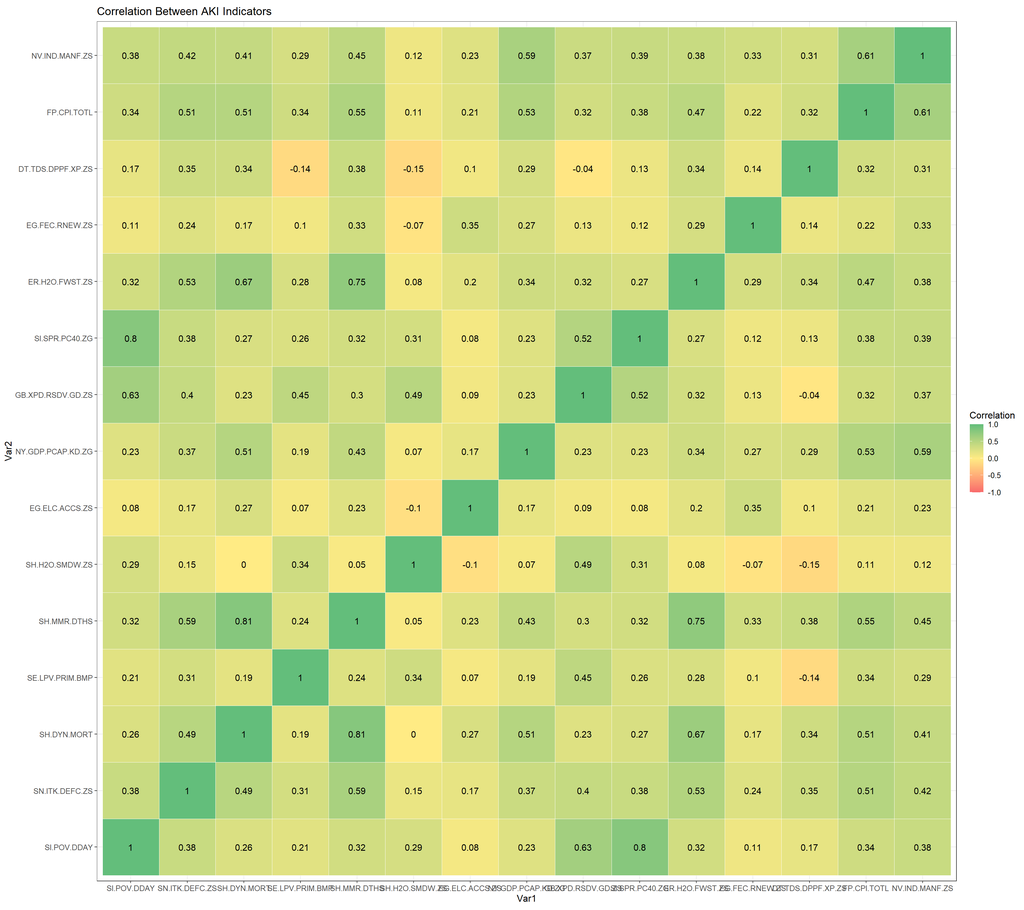

# Full Set of Indicators Recommended by WDI team

Additionally, led by Hiroko, we have a list of SDG indicators here suggested by the WDI team based on the criteria above. Below are the recommendations by the WDI team.

| UNSD Indicator Code* | Target | Indicator | SPI candidates | Types of data | Notes for SPI |
| --- | --- | --- | --- | --- | --- |
| C010201 | 1.2 By 2030, reduce at least by half the proportion of men, women and children of all ages living in poverty in all its dimensions according to national definitions | 1.2.1 Proportion of population living below the national poverty line, by sex and age | SI.POV.NAHC | HHS | For poverty, I think the latest version of the SPI made a sensible choice: I would suggest using whether a poverty headcount ratio at the national poverty line exists within three years. This headcoun… |
| C020101 | 2.1 By 2030, end hunger and ensure access by all people, in particular the poor and people in vulnerable situations, including infants, to safe, nutritious and sufficient food all year round | 2.1.1 Prevalence of undernourishment | SN.ITK.DEFC.ZS | Food balance sheet orignally based on admin data or surveys | Although FAO estimates the undenourished prevalence for all countries, the indicator is not applicable to high income countries. |
| C020201 | 2.2 By 2030, end all forms of malnutrition, including achieving, by 2025, the internationally agreed targets on stunting and wasting in children under 5 years of age, and address the nutritional needs… | 2.2.1 Prevalence of stunting (height for age <-2 standard deviation from the median of the World Health Organization (WHO) Child Growth Standards) among children under 5 years of age | SH.STA.STNT.ZS | HHS | I do not highly recommend this indicator because the data come mostly from household surveys, which availability & quality is not a good indication of NSO’s capacity. Or it should at least be treated … |
| C030101 | 3.1 By 2030, reduce the global maternal mortality ratio to less than 70 per 100,000 live births | 3.1.1 Maternal mortality ratio | SH.STA.MMRT.NE | HHS and Vital Registration | One can check whether the admin data are available, and/or used for the SDG estimation (if used, good quality) on WHO’s (Inter-agency’s) website at https://www.who.int/gho/maternal_health/countries/en… |
| C030201 | 3.2 By 2030, end preventable deaths of newborns and children under 5 years of age, with all countries aiming to reduce neonatal mortality to at least as low as 12 per 1,000 live births and under-5 mor… | 3.2.1 Under‑5 mortality rate | SH.DYN.MORT | HHS and Vital Registration | One can check wheather the admin data are available, and/or used for the SDG estimation (if used, good quality) on Inter-agency’s website at https://childmortality.org/data |
| C030b01 | 3.b Support the research and development of vaccines and medicines for the communicable and non‑communicable diseases that primarily affect developing countries, provide access to affordable essential… | 3.b.1 Proportion of the target population covered by all vaccines included in their national programme | SH.IMM.MEAS | Admin records | One can check whether the admin data are available, and/or used (or close) for the SDG estimation (if used, good quality) on WHO’s website http://apps.who.int/immunization_monitoring/globalsummary/wuc… |
| C040101 | 4.1 By 2030, ensure that all girls and boys complete free, equitable and quality primary and secondary education leading to relevant and effective learning outcomes | 4.1.1 Proportion of children and young people (a) in grades 2/3; (b) at the end of primary; and (c) at the end of lower secondary achieving at least a minimum proficiency level in (i) reading and (ii)… | SE.SEC.CMPT.LO.ZS | Admin records | Gender Parity Index (enrollment), Goal 5 |
| C040202 | NA | 4.2.2 Participation rate in organized learning (one year before the official primary entry age), by sex | Gender Partiy Index (enrollment) | NA | NA |
| C060101 | 6.1 By 2030, achieve universal and equitable access to safe and affordable drinking water for all | 6.1.1 Proportion of population using safely managed drinking water services | SH.H2O.BASW.ZS | HHS, Admin records | NA |
| C060402 | NA | 6.4.2 Level of water stress: freshwater withdrawal as a proportion of available freshwater resources | ER.H2O.FWTL.ZS | NA | NA |
| C070101 | 7.1 By 2030, ensure universal access to affordable, reliable and modern energy services | 7.1.1 Proportion of population with access to electricity | EG.ELC.ACCS.ZS | HHS | NA |
| C070201 | 7.2 By 2030, increase substantially the share of renewable energy in the global energy mix | 7.2.1 Renewable energy share in the total final energy consumption | EG.FEC.RNEW.ZSEG.ELC.RNEW.ZS | NA | NA |
| C080101 | 8.1 Sustain per capita economic growth in accordance with national circumstances and, in particular, at least 7 per cent gross domestic product growth per annum in the least developed countries | 8.1.1 Annual growth rate of real GDP per capita | NY.GDP.PCAP.KD.ZG | SNA and POP | NA |
| C090201 | 9.2 Promote inclusive and sustainable industrialization and, by 2030, significantly raise industry’s share of employment and gross domestic product, in line with national circumstances, and double its… | 9.2.1 Manufacturing value added as a proportion of GDP and per capita | NV.IND.MANF.ZS | NA | NA |
| C090501 | 9.5 Enhance scientific research, upgrade the technological capabilities of industrial sectors in all countries, in particular developing countries, including, by 2030, encouraging innovation and subst… | 9.5.1 Research and development expenditure as a proportion of GDP | GB.XPD.RSDV.GD.ZS | R&D surveys conducted by the ministry responsible for S&T or its equivalent or its delegate under the authority of the NSO. | Innovation is now universally regarded as an engine of economic growth for both developing and developed countries, thus acting as an important driver for poverty alleviation. To set effective innovat… |
| C100101 | 10.1 By 2030, progressively achieve and sustain income growth of the bottom 40 per cent of the population at a rate higher than the national average | 10.1.1 Growth rates of household expenditure or income per capita among the bottom 40 per cent of the population and the total population | SI.SPR.PCAP.ZG | HHS | NA |
| C110101 | 11.1 By 2030, ensure access for all to adequate, safe and affordable housing and basic services and upgrade slums | 11.1.1 Proportion of urban population living in slums, informal settlements or inadequate housing | SP.URB.GROW | NA | SP.URB.GROW is modelled or estimated by UN Population Division, therefore I don’t think it measures NSO’s capacity directly. (Emi) |
| C120301 | 12.3 By 2030, halve per capita global food waste at the retail and consumer levels and reduce food losses along production and supply chains, including post-harvest losses | 12.3.1 (a) Food loss index and (b) food waste index | Global food loss index | NA | Candidate for WDI |
| C140401 | 14.4 By 2020, effectively regulate harvesting and end overfishing, illegal, unreported and unregulated fishing and destructive fishing practices and implement science-based management plans, in order … | 14.4.1 Proportion of fish stocks within biologically sustainable levels | ER.FSH.PROD.MT | NA | NA |
| C160901 | 16.9 By 2030, provide legal identity for all, including birth registration | 16.9.1 Proportion of children under 5 years of age whose births have been registered with a civil authority, by age | SP.REG.BRTH.ZS? | HHS | NA |
| C170401 | 17.4 Assist developing countries in attaining long-term debt sustainability through coordinated policies aimed at fostering debt financing, debt relief and debt restructuring, as appropriate, and addr… | 17.4.1 Debt service as a proportion of exports of goods and services | DT.TDS.DPPF.XP.ZS | NA | NA |
| C170801 | 17.8 Fully operationalize the technology bank and science, technology and innovation capacity-building mechanism for least developed countries by 2017 and enhance the use of enabling technology, in pa… | 17.8.1 Proportion of individuals using the Internet | IT.NET.USER.ZS | Household statistics on ICT access and use are mainly produced by national statistical offices (NSOs) using traditional household surveys. | ICT statistics have been on the agenda of the international statistical community for many years and are receiving increasing attention due to the impact these technologies have on the economy and soc… |